# Using computer adaptive testing to improve migraine outcomes

Erin M. Buchanan

2021-12-20

# Outline

- Migraine Background
- Previous Assessment Work
  - Themes
  - Traditional EFA Development
- Current Goals
  - Phone App Tracker
  - Computer Adaptive Assessment
  - Multigroup or DIF analysis

# What is a headache?

- Head pain that is unpleasant, ranging from mild to severe
- Pressure and aching
- Triggers include stress, anxiety, sinus
- Nearly everyone experiences these

# What is a migraine?

- Often characterized as an “attack”
- Moderate to severe pain
- Comorbid with visual disturbances, nausea, vomiting, sensitivity to light/sound/smell, auras
- ~12% of the population experiences these

# Infographic

[figure not shown]

# Fast facts

- 3rd most prevalent illness in the world
- A woman’s illness
- Often 1-2 attacks per month, others are chronic with 15+ per month
- Serious impacts on work, family, and daily life

# Previous work

- We developed the Functional Assessment of Migraine Scale to measure response to treatment across a wide variety of patient concerns
  - First, we established factors that were indicated as most important to patients when appraising the efficacy of treatment
  - Second, we developed a patient reported outcome measure to evaluate headache meaningful response to headache treatment regimens
- Why?
  - Migraine Disability Assessment (MIDAS): 5 items measuring loss of productivity across work and social/family
  - Headache Impact Test (HIT-6): 6 items measuring lost work time, pain severity, fatigue

# What is important?

- Two Main Results:
  - Rating of importance for our preselected themes
  - Thematic Analysis of open ended responses

# Ratings

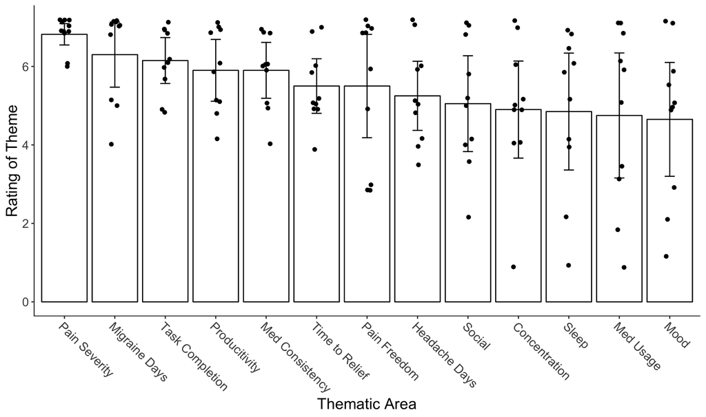

# Thematic analysis

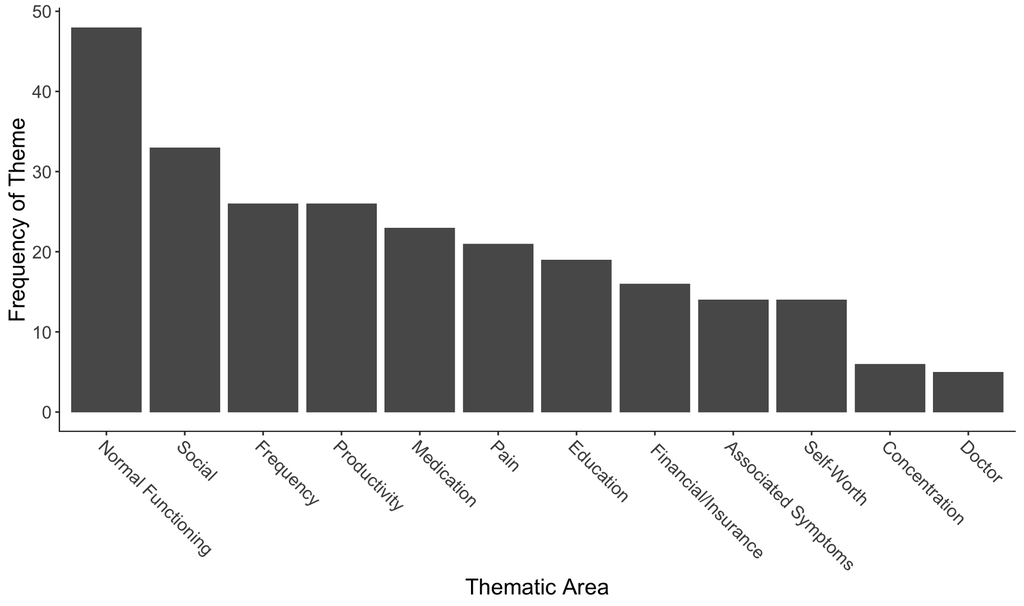

# Traditional EFA Development

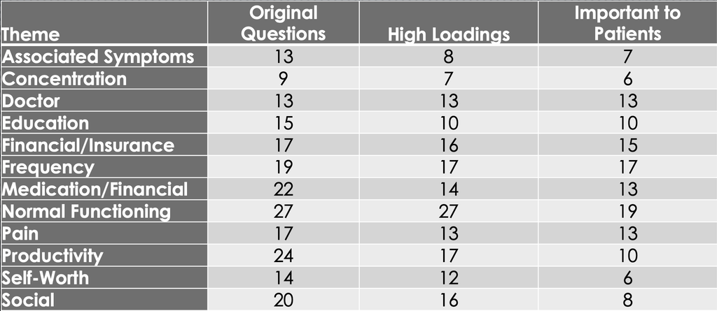

# Finalized Scale

- The FAMS is a set of scales:
  - Research (18 items)
  - Clinical (9 items)
  - Supplemental (9 items)
- Psychometrics appear to support reliability, validity, and predictive usefulness.

# Current Goals

[figure not shown]

# Implement CAT

[output not shown]

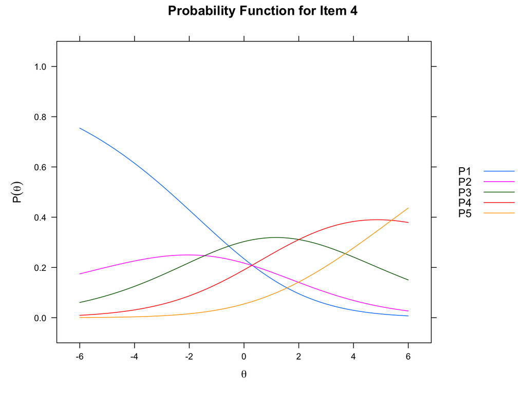

# Implement CAT

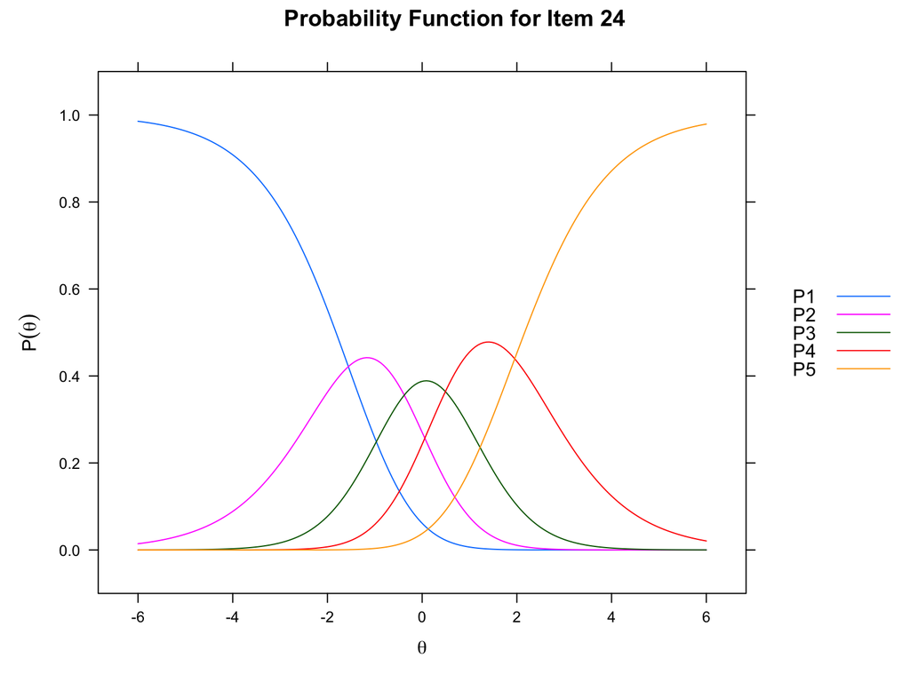

# Implement CAT

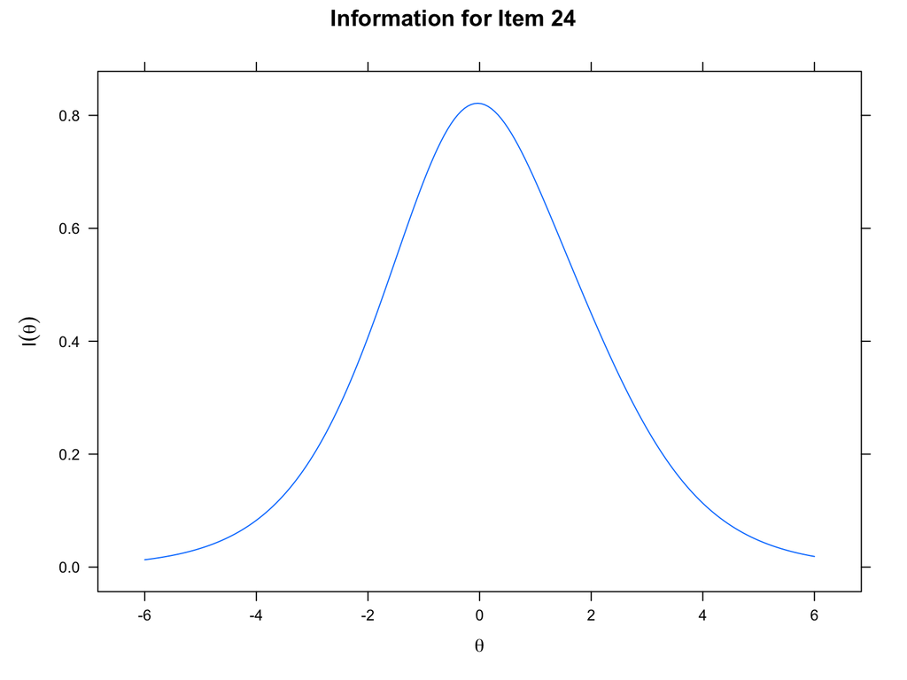

# Implement CAT

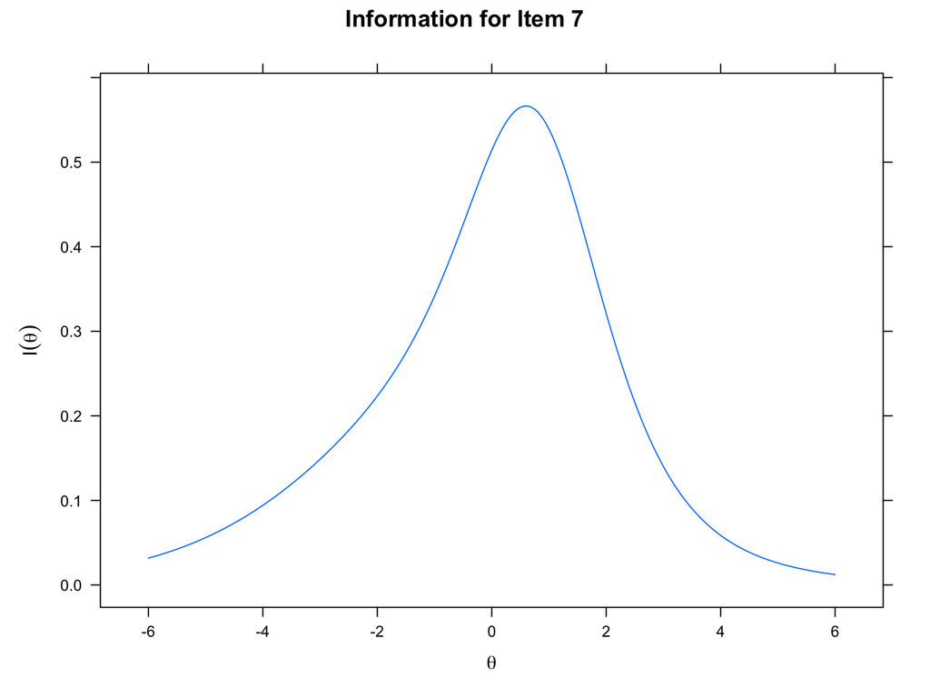

# Implement CAT

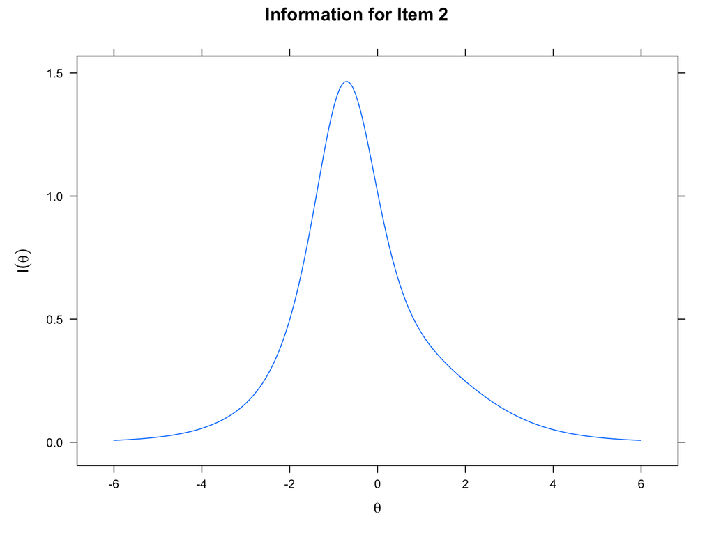

# Next steps

- Collect more data!
- Separate models for episodic and chronic patients indicate similar scale functioning for each subset of patients
  - A small amount of evidence that these may be equivalent
  - Ensure each population represented in data
- Update based on feedback

# Thanks for listening!

- Migraine is a multi-faceted illness with many factors to consider!
- Thanks to Clinvest Research, Harrisburg University, and the National Headache Foundation for supporting this research.
- Questions?